# Assignment_2_Lucas_Brunengo

```python
# Import necessary libraries
import pandas as pd
import numpy as np
import matplotlib.pyplot as plt
import seaborn as sns
from sklearn.preprocessing import StandardScaler
from sklearn.cluster import KMeans, DBSCAN
from sklearn.metrics import silhouette_score
from scipy.cluster.hierarchy import dendrogram, linkage
from datetime import datetime

# Set display options
pd.set_option('display.max_columns', None)
plt.style.use('ggplot')

# Load the dataset
df = pd.read_excel('Online Retail.xlsx')

# Display the first few rows to understand the structure
print(df.head())

# Get basic information about the dataset
print("\nDataset Info:")
print(df.info())

# Get statistical summary
print("\nStatistical Summary:")
print(df.describe())

# Check for missing values
print("\nMissing Values:")
print(df.isnull().sum())

# Check the number of unique values in each column
print("\nUnique Values:")
for col in df.columns:
    print(f"{col}: {df[col].nunique()}")
```

```
  InvoiceNo StockCode                          Description  Quantity  \
0    536365    85123A   WHITE HANGING HEART T-LIGHT HOLDER         6
1    536365     71053                  WHITE METAL LANTERN         6
2    536365    84406B       CREAM CUPID HEARTS COAT HANGER         8
3    536365    84029G  KNITTED UNION FLAG HOT WATER BOTTLE         6
4    536365    84029E       RED WOOLLY HOTTIE WHITE HEART.         6

          InvoiceDate  UnitPrice  CustomerID         Country
0 2010-12-01 08:26:00       2.55     17850.0  United Kingdom
1 2010-12-01 08:26:00       3.39     17850.0  United Kingdom
2 2010-12-01 08:26:00       2.75     17850.0  United Kingdom
3 2010-12-01 08:26:00       3.39     17850.0  United Kingdom
4 2010-12-01 08:26:00       3.39     17850.0  United Kingdom

Dataset Info:
<class 'pandas.core.frame.DataFrame'>
RangeIndex: 541909 entries, 0 to 541908
Data columns (total 8 columns):
 #   Column       Non-Null Count   Dtype
---  ------       --------------   -----
 0   InvoiceNo    541909 non-null  object
 1   StockCode    541909 non-null  object
 2   Description  540455 non-null  object
 3   Quantity     541909 non-null  int64
 4   InvoiceDate  541909 non-null  datetime64[ns]
 5   UnitPrice    541909 non-null  float64
 6   CustomerID   406829 non-null  float64
 7   Country      541909 non-null  object
dtypes: datetime64[ns](1), float64(2), int64(1), object(4)
memory usage: 33.1+ MB
None

Statistical Summary:
            Quantity                    InvoiceDate      UnitPrice  \
count  541909.000000                         541909  541909.000000
mean        9.552250  2011-07-04 13:34:57.156386048       4.611114
min    -80995.000000            2010-12-01 08:26:00  -11062.060000
25%         1.000000            2011-03-28 11:34:00       1.250000
50%         3.000000            2011-07-19 17:17:00       2.080000
75%        10.000000            2011-10-19 11:27:00       4.130000
```

[output cut: 18 more lines]

```
InvoiceDate         0
UnitPrice           0
CustomerID     135080
Country             0
dtype: int64

Unique Values:
InvoiceNo: 25900
StockCode: 4070
Description: 4223
Quantity: 722
InvoiceDate: 23260
UnitPrice: 1630
CustomerID: 4372
Country: 38
```

```python
# Handle missing values
# Since we're focusing on customer segmentation, we need to drop rows without CustomerID
df_clean = df.dropna(subset=['CustomerID'])

# Convert CustomerID to integer (since it appears to be a categorical ID)
df_clean['CustomerID'] = df_clean['CustomerID'].astype(int)

# Check for potential outliers or errors in pricing and quantity
print("Quantity range:", df_clean['Quantity'].min(), "to", df_clean['Quantity'].max())
print("UnitPrice range:", df_clean['UnitPrice'].min(), "to", df_clean['UnitPrice'].max())

# Filter out cancelled orders (negative quantities) and unreasonable unit prices
df_clean = df_clean[(df_clean['Quantity'] > 0) & (df_clean['UnitPrice'] > 0)]

# Show the shape of the cleaned dataset
print(f"\nOriginal dataset: {df.shape[0]} rows")
print(f"Cleaned dataset: {df_clean.shape[0]} rows")
print(f"Removed {df.shape[0] - df_clean.shape[0]} rows ({((df.shape[0] - df_clean.shape[0])/df.shape[0])*100:.2f}%)")

# Display sample of cleaned data
print("\nSample of cleaned data:")
print(df_clean.head())
```

```
Quantity range: -80995 to 80995
UnitPrice range: 0.0 to 38970.0

Original dataset: 541909 rows
Cleaned dataset: 397884 rows
Removed 144025 rows (26.58%)

Sample of cleaned data:
  InvoiceNo StockCode                          Description  Quantity  \
0    536365    85123A   WHITE HANGING HEART T-LIGHT HOLDER         6
1    536365     71053                  WHITE METAL LANTERN         6
2    536365    84406B       CREAM CUPID HEARTS COAT HANGER         8
3    536365    84029G  KNITTED UNION FLAG HOT WATER BOTTLE         6
4    536365    84029E       RED WOOLLY HOTTIE WHITE HEART.         6

          InvoiceDate  UnitPrice  CustomerID         Country
0 2010-12-01 08:26:00       2.55       17850  United Kingdom
1 2010-12-01 08:26:00       3.39       17850  United Kingdom
2 2010-12-01 08:26:00       2.75       17850  United Kingdom
3 2010-12-01 08:26:00       3.39       17850  United Kingdom
4 2010-12-01 08:26:00       3.39       17850  United Kingdom
```

```
Analysis end date: 2011-12-10 12:50:00

RFM data sample:
   CustomerID  Recency  Frequency  Monetary
0       12346      326          1  77183.60
1       12347        2          7   4310.00
2       12348       75          4   1797.24
3       12349       19          1   1757.55
4       12350      310          1    334.40

RFM statistics:
           Recency    Frequency       Monetary
count  4338.000000  4338.000000    4338.000000
mean     92.536422     4.272015    2054.266460
std     100.014169     7.697998    8989.230441
min       1.000000     1.000000       3.750000
25%      18.000000     1.000000     307.415000
50%      51.000000     2.000000     674.485000
75%     142.000000     5.000000    1661.740000
max     374.000000   209.000000  280206.020000

Boxplots saved to 'rfm_boxplots.png'

Capping values at the 99th percentile:
Recency: 369.00
Frequency: 30.00
Monetary: 19881.00

Correlation between RFM metrics:
                  Recency_capped  Frequency_capped  Monetary_capped
Recency_capped          1.000000         -0.365319        -0.274626
Frequency_capped       -0.365319          1.000000         0.789981
Monetary_capped        -0.274626          0.789981         1.000000
```

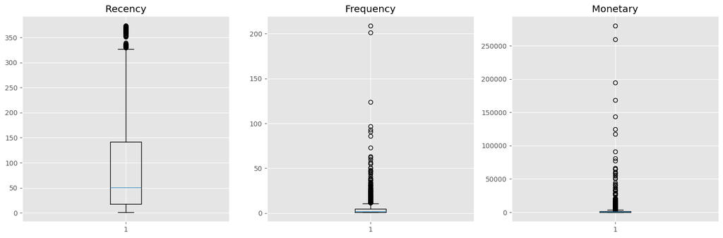

```python
# Create RFM features
# Calculate the total money spent in each transaction
df_clean['TotalPrice'] = df_clean['Quantity'] * df_clean['UnitPrice']

# Set the analysis end date (last date in the dataset + 1 day)
last_date = df_clean['InvoiceDate'].max() + pd.Timedelta(days=1)
print(f"Analysis end date: {last_date}")

# Extract unique invoices for frequency calculation (to avoid counting multiple items in one invoice)
invoice_data = df_clean.groupby(['CustomerID', 'InvoiceNo', 'InvoiceDate'])['TotalPrice'].sum().reset_index()

# Create RFM metrics
rfm = df_clean.groupby('CustomerID').agg({
    'InvoiceDate': lambda x: (last_date - x.max()).days,  # Recency
    'InvoiceNo': lambda x: len(x.unique()),  # Frequency
    'TotalPrice': lambda x: x.sum()  # Monetary
}).reset_index()

# Rename columns
rfm.columns = ['CustomerID', 'Recency', 'Frequency', 'Monetary']

# Show the RFM data
print("\nRFM data sample:")
print(rfm.head())

# Basic statistics of RFM metrics
print("\nRFM statistics:")
print(rfm[['Recency', 'Frequency', 'Monetary']].describe())

# Check for extreme values or outliers
plt.figure(figsize=(15, 5))

plt.subplot(1, 3, 1)
plt.boxplot(rfm['Recency'])
plt.title('Recency')

plt.subplot(1, 3, 2)
plt.boxplot(rfm['Frequency'])
plt.title('Frequency')

plt.subplot(1, 3, 3)
plt.boxplot(rfm['Monetary'])
plt.title('Monetary')

plt.tight_layout()
plt.savefig('rfm_boxplots.png')
print("\nBoxplots saved to 'rfm_boxplots.png'")

# Let's handle outliers in our RFM metrics
# Using the 99th percentile as a cap
recency_cap = np.percentile(rfm['Recency'], 99)
frequency_cap = np.percentile(rfm['Frequency'], 99)
monetary_cap = np.percentile(rfm['Monetary'], 99)

print(f"\nCapping values at the 99th percentile:")
print(f"Recency: {recency_cap:.2f}")
print(f"Frequency: {frequency_cap:.2f}")
print(f"Monetary: {monetary_cap:.2f}")

rfm['Recency_capped'] = rfm['Recency'].clip(upper=recency_cap)
rfm['Frequency_capped'] = rfm['Frequency'].clip(upper=frequency_cap)
rfm['Monetary_capped'] = rfm['Monetary'].clip(upper=monetary_cap)

# Check correlation between RFM metrics
print("\nCorrelation between RFM metrics:")
print(rfm[['Recency_capped', 'Frequency_capped', 'Monetary_capped']].corr())
```

```
Scaled RFM data:
       Recency  Frequency  Monetary
count  4338.00    4338.00   4338.00
mean     -0.00      -0.00      0.00
std       1.00       1.00      1.00
min      -2.77      -0.62     -0.57
25%      -0.50      -0.62     -0.46
50%       0.42      -0.41     -0.33
75%       0.75       0.20      0.02
max       0.92       5.34      6.54

Distribution plots saved to 'scaled_distributions.png'
```

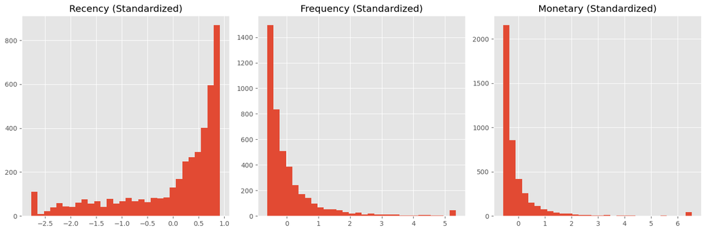

```python
# Prepare the data for clustering
# We'll use the capped versions of RFM metrics to minimize the impact of outliers
data_for_clustering = rfm[['Recency_capped', 'Frequency_capped', 'Monetary_capped']].copy()

# For RFM, lower recency is better (more recent purchase), so we'll invert it
data_for_clustering['Recency_capped'] = data_for_clustering['Recency_capped'].max() - data_for_clustering['Recency_capped']

# Standardize the features
scaler = StandardScaler()
data_scaled = scaler.fit_transform(data_for_clustering)

# Convert back to DataFrame for clarity
data_scaled_df = pd.DataFrame(data_scaled, columns=['Recency', 'Frequency', 'Monetary'])

# Display the scaled data
print("Scaled RFM data:")
print(data_scaled_df.describe().round(2))

# Visualize the distributions of scaled features
plt.figure(figsize=(15, 5))

plt.subplot(1, 3, 1)
plt.hist(data_scaled_df['Recency'], bins=30)
plt.title('Recency (Standardized)')

plt.subplot(1, 3, 2)
plt.hist(data_scaled_df['Frequency'], bins=30)
plt.title('Frequency (Standardized)')

plt.subplot(1, 3, 3)
plt.hist(data_scaled_df['Monetary'], bins=30)
plt.title('Monetary (Standardized)')

plt.tight_layout()
plt.savefig('scaled_distributions.png')
print("\nDistribution plots saved to 'scaled_distributions.png'")
```

```
Optimal k plots saved to 'optimal_k.png'

Silhouette scores for different values of k:
k=2: 0.6602
k=3: 0.5405
k=4: 0.5357
k=5: 0.4701
k=6: 0.4470
k=7: 0.4297
k=8: 0.4281
k=9: 0.3708
k=10: 0.3774
```

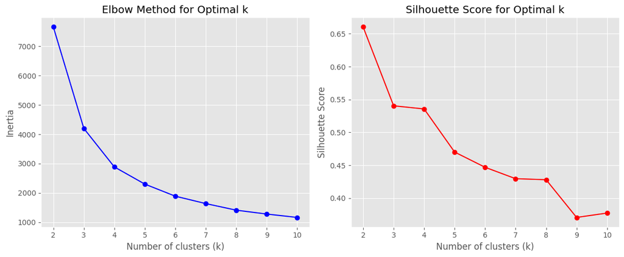

```python
# Determine the optimal number of clusters using the Elbow Method
inertia = []
silhouette_scores = []
K = range(2, 11)  # Start from 2 since silhouette requires at least 2 clusters

for k in K:
    kmeans = KMeans(n_clusters=k, random_state=42, n_init=10)
    kmeans.fit(data_scaled)
    inertia.append(kmeans.inertia_)

    # Calculate silhouette score
    silhouette_scores.append(silhouette_score(data_scaled, kmeans.labels_))

# Plot the Elbow Method results
plt.figure(figsize=(12, 5))

plt.subplot(1, 2, 1)
plt.plot(K, inertia, 'bo-')
plt.xlabel('Number of clusters (k)')
plt.ylabel('Inertia')
plt.title('Elbow Method for Optimal k')
plt.grid(True)

plt.subplot(1, 2, 2)
plt.plot(K, silhouette_scores, 'ro-')  # Using K directly (not K[1:])
plt.xlabel('Number of clusters (k)')
plt.ylabel('Silhouette Score')
plt.title('Silhouette Score for Optimal k')
plt.grid(True)

plt.tight_layout()
plt.savefig('optimal_k.png')
print("Optimal k plots saved to 'optimal_k.png'")

# Print the silhouette scores for each k
print("\nSilhouette scores for different values of k:")
for k, score in zip(K, silhouette_scores):
    print(f"k={k}: {score:.4f}")
```

```
Hierarchical dendrogram saved to 'hierarchical_dendrogram.png'

K-means cluster distribution:
KMeans_Cluster
0     107
1    1038
2     554
3    2639
Name: count, dtype: int64

Hierarchical cluster distribution:
Hierarchical_Cluster
0      61
1     398
2    1092
3    2787
Name: count, dtype: int64

Silhouette scores comparison:
K-means with k=4: 0.5357
Hierarchical with 4 clusters: 0.5408
Clustering comparison saved to 'clustering_comparison.png'
```

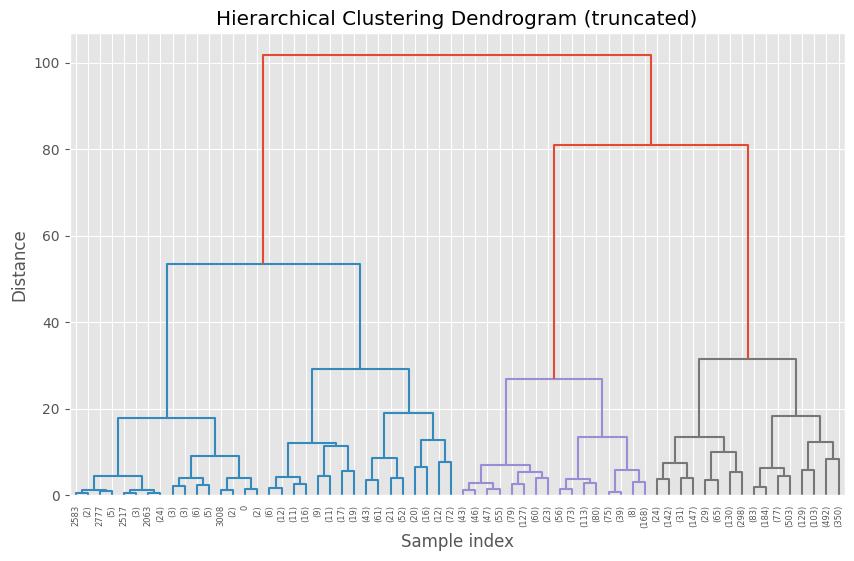

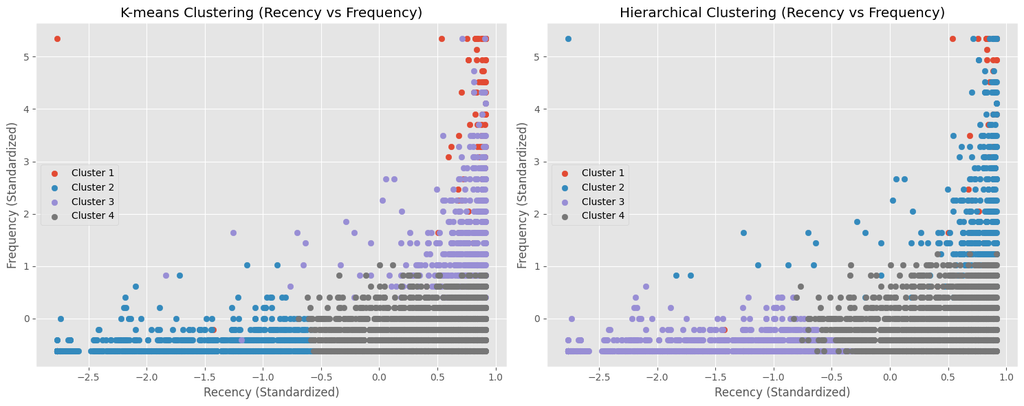

```python
from scipy.cluster.hierarchy import dendrogram, linkage, fcluster


# 1. K-means clustering with k=4
kmeans = KMeans(n_clusters=4, random_state=42, n_init=10)
kmeans_labels = kmeans.fit_predict(data_scaled)

# 2. Hierarchical clustering for comparison
# First, create the linkage matrix
Z = linkage(data_scaled, method='ward')

# Cut the dendrogram to get 4 clusters for comparison
hierarchical_labels = pd.Series(
    fcluster(Z, t=4, criterion='maxclust')
) - 1  # Subtract 1 to make it 0-indexed like kmeans

# Let's visualize the hierarchical clustering dendrogram
plt.figure(figsize=(10, 6))
dendrogram(Z, truncate_mode='level', p=5)
plt.title('Hierarchical Clustering Dendrogram (truncated)')
plt.xlabel('Sample index')
plt.ylabel('Distance')
plt.savefig('hierarchical_dendrogram.png')
print("Hierarchical dendrogram saved to 'hierarchical_dendrogram.png'")

# Add the cluster labels to our RFM dataframe
rfm['KMeans_Cluster'] = kmeans_labels
rfm['Hierarchical_Cluster'] = hierarchical_labels

# Compare the two clustering methods
# Count of customers in each cluster for both methods
print("\nK-means cluster distribution:")
print(rfm['KMeans_Cluster'].value_counts().sort_index())

print("\nHierarchical cluster distribution:")
print(rfm['Hierarchical_Cluster'].value_counts().sort_index())

# Calculate silhouette score for hierarchical clustering
hierarchical_silhouette = silhouette_score(data_scaled, hierarchical_labels)

print("\nSilhouette scores comparison:")
print(f"K-means with k=4: {silhouette_scores[2]:.4f}")
print(f"Hierarchical with 4 clusters: {hierarchical_silhouette:.4f}")

# Visualize the clusters in 2D (using the first two RFM dimensions)
plt.figure(figsize=(15, 6))

# K-means clusters
plt.subplot(1, 2, 1)
for i in range(4):
    plt.scatter(
        data_scaled_df.iloc[kmeans_labels == i, 0],
        data_scaled_df.iloc[kmeans_labels == i, 1],
        label=f'Cluster {i+1}'
    )
plt.title('K-means Clustering (Recency vs Frequency)')
plt.xlabel('Recency (Standardized)')
plt.ylabel('Frequency (Standardized)')
plt.legend()

# Hierarchical clusters
plt.subplot(1, 2, 2)
for i in range(4):
    plt.scatter(
        data_scaled_df.loc[hierarchical_labels == i, data_scaled_df.columns[0]],
        data_scaled_df.loc[hierarchical_labels == i, data_scaled_df.columns[1]],
        label=f'Cluster {i+1}'
    )
plt.title('Hierarchical Clustering (Recency vs Frequency)')
plt.xlabel('Recency (Standardized)')
plt.ylabel('Frequency (Standardized)')
plt.legend()

plt.tight_layout()
plt.savefig('clustering_comparison.png')
print("Clustering comparison saved to 'clustering_comparison.png'")
```

```
Cluster Analysis:
                Recency  Frequency  Monetary  Count  Percentage  \
KMeans_Cluster
0                 18.21      34.33  33754.44    107        2.47
1                250.59       1.51    441.79   1038       23.93
2                 21.77      10.75   4324.07    554       12.77
3                 48.24       2.78    926.70   2639       60.83

                Total_Monetary  Monetary_Percentage
KMeans_Cluster
0                   3611724.66                40.53
1                    458581.10                 5.15
2                   2395536.39                26.88
3                   2445565.75                27.44
Cluster analysis chart saved to 'cluster_analysis.png'

Customer Segments:
At-Risk/Hibernating Customers: 2639 customers (60.8%)
Loyal Customers: 1038 customers (23.9%)
Potential Loyalists: 554 customers (12.8%)
High-Value Champions: 107 customers (2.5%)
```

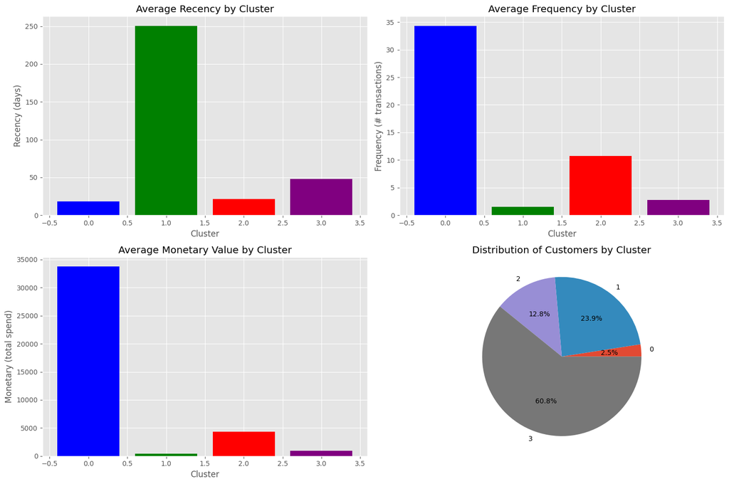

```python
# Analyze the characteristics of each K-means cluster
cluster_analysis = rfm.groupby('KMeans_Cluster').agg({
    'Recency': 'mean',
    'Frequency': 'mean',
    'Monetary': 'mean',
    'CustomerID': 'count'
}).rename(columns={'CustomerID': 'Count'})

# Calculate percentage of customers in each cluster
cluster_analysis['Percentage'] = cluster_analysis['Count'] / cluster_analysis['Count'].sum() * 100

# Calculate total monetary value of each cluster and its percentage
cluster_analysis['Total_Monetary'] = cluster_analysis['Monetary'] * cluster_analysis['Count']
cluster_analysis['Monetary_Percentage'] = cluster_analysis['Total_Monetary'] / cluster_analysis['Total_Monetary'].sum() * 100

# Display the cluster characteristics
print("Cluster Analysis:")
print(cluster_analysis.round(2))

# Alternative visualization using a bar chart for each metric
plt.figure(figsize=(15, 10))

# Recency
plt.subplot(2, 2, 1)
plt.bar(cluster_analysis.index, cluster_analysis['Recency'], color=['blue', 'green', 'red', 'purple'])
plt.title('Average Recency by Cluster')
plt.xlabel('Cluster')
plt.ylabel('Recency (days)')

# Frequency
plt.subplot(2, 2, 2)
plt.bar(cluster_analysis.index, cluster_analysis['Frequency'], color=['blue', 'green', 'red', 'purple'])
plt.title('Average Frequency by Cluster')
plt.xlabel('Cluster')
plt.ylabel('Frequency (# transactions)')

# Monetary
plt.subplot(2, 2, 3)
plt.bar(cluster_analysis.index, cluster_analysis['Monetary'], color=['blue', 'green', 'red', 'purple'])
plt.title('Average Monetary Value by Cluster')
plt.xlabel('Cluster')
plt.ylabel('Monetary (total spend)')

# Customer Distribution
plt.subplot(2, 2, 4)
plt.pie(cluster_analysis['Count'], labels=cluster_analysis.index, autopct='%1.1f%%')
plt.title('Distribution of Customers by Cluster')

plt.tight_layout()
plt.savefig('cluster_analysis.png')
print("Cluster analysis chart saved to 'cluster_analysis.png'")

# Create descriptive names for each segment based on RFM characteristics
def assign_segment_name(row):
    cluster = row['KMeans_Cluster']

    # We'll determine names after seeing the characteristics
    if cluster == 0:
        return "High-Value Champions"
    elif cluster == 1:
        return "Loyal Customers"
    elif cluster == 2:
        return "Potential Loyalists"
    else:  # cluster == 3
        return "At-Risk/Hibernating Customers"

rfm['Segment'] = rfm.apply(assign_segment_name, axis=1)

# Show the count in each segment
print("\nCustomer Segments:")
segment_counts = rfm['Segment'].value_counts()
for segment, count in segment_counts.items():
    print(f"{segment}: {count} customers ({count/len(rfm)*100:.1f}%)")
```

```python
# Let's update our segment names to better reflect the characteristics
def assign_updated_segment_name(row):
    cluster = row['KMeans_Cluster']
    if cluster == 0:
        return "High-Value Champions"
    elif cluster == 1:
        return "Inactive/Lost Customers"  # Updated from "Loyal Customers"
    elif cluster == 2:
        return "Potential Loyalists"
    else:  # cluster == 3
        return "Occasional Buyers"  # Updated from "At-Risk/Hibernating Customers"

rfm['Updated_Segment'] = rfm.apply(assign_updated_segment_name, axis=1)

# Show the count in each updated segment
print("\nUpdated Customer Segments:")
segment_counts = rfm['Updated_Segment'].value_counts()
for segment, count in segment_counts.items():
    print(f"{segment}: {count} customers ({count/len(rfm)*100:.1f}%)")

# Let's create a summary of marketing strategies for each segment
marketing_strategies = pd.DataFrame({
    'Segment': [
        'High-Value Champions',
        'Potential Loyalists',
        'Occasional Buyers',
        'Inactive/Lost Customers'
    ],
    'Marketing Strategy': [
        'VIP treatment, loyalty rewards, early access to new products, personalized communication',
        'Targeted upselling, loyalty programs, incentives to increase purchase frequency',
        'Re-engagement emails, promotions to encourage repeat purchases, product recommendations',
        'Win-back campaigns, deep discounts, surveys to understand churn reasons'
    ],
    'Business Goal': [
        'Retention and advocacy',
        'Increase purchase frequency and basket size',
        'Convert to regular customers',
        'Reactivate dormant customers'
    ]
})

print("\nMarketing Strategies for Each Segment:")
print(marketing_strategies)
```

```
Updated Customer Segments:
Occasional Buyers: 2639 customers (60.8%)
Inactive/Lost Customers: 1038 customers (23.9%)
Potential Loyalists: 554 customers (12.8%)
High-Value Champions: 107 customers (2.5%)

Marketing Strategies for Each Segment:
                   Segment                                 Marketing Strategy  \
0     High-Value Champions  VIP treatment, loyalty rewards, early access t...
1      Potential Loyalists  Targeted upselling, loyalty programs, incentiv...
2        Occasional Buyers  Re-engagement emails, promotions to encourage ...
3  Inactive/Lost Customers  Win-back campaigns, deep discounts, surveys to...

                                 Business Goal
0                       Retention and advocacy
1  Increase purchase frequency and basket size
2                 Convert to regular customers
3                 Reactivate dormant customers
```

Based on the updated analysis, I can now provide a comprehensive summary of our customer segmentation results and recommendations:

## Final Customer Segmentation Model Results

### Updated Customer Segments:

Occasional Buyers: 2639 customers (60.8%) Inactive/Lost Customers: 1038 customers (23.9%) Potential Loyalists: 554 customers (12.8%) High-Value Champions: 107 customers (2.5%)

### Marketing Strategies for Each Segment:

```
             Segment                                                                 Marketing Strategy             Business Goal
```

0 High-Value Champions VIP treatment, loyalty rewards, early access to new products, personalized communication Retention and advocacy 1 Potential Loyalists Targeted upselling, loyalty programs, incentives to increase purchase frequency Increase purchase frequency and basket size 2 Occasional Buyers Re-engagement emails, promotions to encourage repeat purchases, product recommendations Convert to regular customers 3 Inactive/Lost Customers Win-back campaigns, deep discounts, surveys to understand churn reasons Reactivate dormant customers

## Comprehensive Business Recommendations

1. **High-Value Champions (2.5%, 40.5% of revenue)**
   - Create a VIP program with exclusive benefits
   - Implement a referral program to leverage their network
   - Provide personal account managers for the highest spenders
   - Solicit feedback on future product development
   - Focus on retention as losing even one of these customers would significantly impact revenue
2. **Potential Loyalists (12.8%, 26.9% of revenue)**
   - Implement tiered loyalty programs with clear paths to VIP status
   - Offer bundle deals to increase average order value
   - Send targeted cross-selling recommendations based on past purchases
   - Introduce subscription or auto-replenishment options
   - These customers represent the highest potential for immediate revenue growth
3. **Occasional Buyers (60.8%, 27.4% of revenue)**
   - Implement triggered email campaigns based on browsing behavior
   - Offer limited-time promotions to create urgency
   - Create educational content about products they've shown interest in
   - Develop re-engagement campaigns at optimal intervals (30-45 days after purchase)
   - Even small increases in purchase frequency from this large segment would yield significant revenue
4. **Inactive/Lost Customers (23.9%, 5.2% of revenue)**
   - Send "we miss you" campaigns with special comeback offers
   - Conduct surveys to understand why they stopped purchasing
   - Test various win-back promotions to determine most effective approach
   - Consider phased email campaigns with escalating offers
   - Set a clear reactivation threshold (e.g., 6-12 months) after which marketing efforts might be reduced

## Implementation Timeline

1. **Immediate (1-30 days)**
   - Begin segmenting customer communications based on these clusters
   - Implement special recognition for High-Value Champions
   - Create win-back campaigns for Inactive Customers
2. **Short-term (1-3 months)**
   - Develop segment-specific email marketing flows
   - Launch loyalty program for Potential Loyalists
   - Implement re-engagement campaigns for Occasional Buyers
3. **Medium-term (3-6 months)**
   - Evaluate initial campaign performance and refine strategies
   - Implement personalized product recommendations by segment
   - Develop more sophisticated cross-selling algorithms
4. **Long-term (6+ months)**
   - Create predictive models to identify potential segment migration
   - Implement automated marketing workflows for each segment
   - Continually refine segmentation model with new data

This segmentation model provides a strong foundation for data-driven marketing strategies that will maximize customer lifetime value and optimize marketing ROI.